# Build priority land-use rasters for Denmark and Gudenå

# 1 Purpose

This workflow combines four sources into one categorical land-use system:

1. the eight `SN_ModelClass` nature types derived from Basemap03;
2. agriculture from Markblokkort;
3. urban and infrastructure classes from Basemap03; and
4. production forest from the **national Basemap forest footprint**.

The last point is deliberate. `Subclasses == "Drevet Skov"` only identifies managed forest inside the protection-scheme footprint. It is useful as an audit, but it cannot be the source for production forest across the whole country. Here, all Basemap forest (`311000` and `312000`) is treated as production forest unless it is explicitly retained as forest nature. This is a **production-forest proxy**, not a verified national inventory of management status. The checkpoint update does not change that ecological assumption.

It writes a national current raster for model fitting and threshold calibration, then crops that exact raster to gudenaa for current and scenario projections. The two rasters therefore use the same codes and factor levels.

The priority order is:

1. nature type;
2. agriculture;
3. urban/infrastructure;
4. production forest; and
5. other land.

Thus, a natural habitat is not overwritten merely because it intersects a Markblokkort polygon. Agriculture still takes priority over production forest. The final `Urban` class is fixed in restoration scenarios. Because agriculture outranks urban here, overlapping Basemap urban/Markblokkort cells are reported in the audit; exclude the original urban footprint in the scenario document if that footprint must never be converted.

# 2 Input folder

`markblokkort_file` may be either:

- a categorical raster whose cells are `INT_AGG`, `PGR`, or the original Markblokkort classes; or
- a vector file with the class field named by `markblokkort_field`.

The categorical baseline is built nationally because model fitting should use the Danish occurrence records and a national predictor domain. Only the final projection copy is cropped to gudenaa. CHELSA is **not** upscaled nationally; the second document aligns climate at 10 m only for the local projection area.

# 3 Restarting without rebuilding everything

Heavy raster stages are saved as compressed GeoTIFFs under `Intermediates/gudenaa_landuse/`. Audit tables are saved as ordinary RDS files. **No `SpatRaster` external pointers are saved in RDS or knitr’s chunk cache.**

- Knit normally. Messages say `[build]` for a new stage and `[reuse]` for a matching completed stage.
- A tiny four-cell self-test checks category saving, reopening, checkpoint reuse, input invalidation, failed-stage retry, and export reuse before any national rasters are processed. Leave `run_checkpoint_smoke_test: true`.
- If knitting stops, fix the error and knit again with the same parameters. Completed stages are reused, including the national raster if a later local crop, audit, export, or plot fails.
- Checkpoints include the stage’s code, relevant helper code, input signatures, parameters, category dictionary where relevant, and upstream checkpoints. Changing only `gudenaa_file` rebuilds the local crop and its audit, not the national classification. Plot/title edits do not rebuild rasters.
- Large input rasters are checked by path, size, and modification time by default; small files (up to 10 MiB), including projection/category sidecars, are also hashed. Set `input_fingerprint: "md5"` for full-file input checks, at the cost of reading every large input on each knit. VRTs are rejected: materialize them to GeoTIFF first so external VRT sources cannot change unnoticed.
- To deliberately rebuild everything, change `checkpoint_revision` from `"v1"` to `"v2"`. Old checkpoints are retained; they are not automatically deleted. Also change this revision after editing an untracked global/helper that you add to the workflow.
- `overwrite` controls **final published outputs**, not checkpoint reuse. Matching outputs from this version are reused even with `overwrite: false`. An older or changed output is protected: choose a new `output_dir`, or set `overwrite: true` only if you intend to replace it.

Each stage has a fingerprint subfolder and a `complete.rds` record, written only after its file has been written and reopened successfully. An interrupted stage without a valid completion record is rebuilt. Do not edit checkpoint files manually, run two knits into the same folders concurrently, or commit `Intermediates/`, source rasters, or generated predictor TIFFs to Git. Old or incomplete checkpoint files consume disk space until you intentionally remove them; keep plenty of space on the working drive.

The first run of this version must build the checkpoints once. It cannot recover unsaved intermediates from an earlier terminated Knit process.

# 4 Data provenance and redistribution

Basemap03 is an Aarhus University/DCE analytical product and is not legally binding. Cite the Basemap03 technical documentation (Levin 2019) in analyses that use this derivative. The derived rasters, Markblokkort data and project `Subclasses` layer must retain their respective source terms and internal data agreements. In particular, do not add large or restricted source rasters to a public Git repository merely because this script can reproduce the derivative; track paths/manifests and documentation in Git, and store the spatial inputs in the approved data location.

```r
knitr::opts_chunk$set(
  collapse = TRUE,
  comment = "#>",
  error = FALSE,
  message = TRUE,
  warning = TRUE,
  cache = FALSE
)

required_packages <- c(
  "terra", "foreign", "dplyr", "readr", "stringr", "tibble", "knitr",
  "digest"
)

missing_packages <- setdiff(
  required_packages,
  rownames(utils::installed.packages())
)

if (length(missing_packages) > 0L) {
  stop(
    "Install the missing packages first: ",
    paste(missing_packages, collapse = ", "),
    call. = FALSE
  )
}

library(terra)
library(dplyr)
terra::terraOptions(progress = 1L, threads = 1L)

if (!params$input_fingerprint %in% c("metadata", "md5")) {
  stop("`input_fingerprint` must be 'metadata' or 'md5'.", call. = FALSE)
}
dir.create(params$intermediate_dir, recursive = TRUE, showWarnings = FALSE)
checkpoint_records <- new.env(parent = emptyenv())
```

# 5 Fixed class dictionary

The IDs are fixed rather than generated from first-seen order. This guarantees that current and scenario rasters have exactly the same interpretation.

```r
landuse_legend <- tibble::tribble(
  ~id, ~class,                  ~role,
    1, "ForestDryPoor",        "nature",
    2, "ForestWetPoor",        "nature",
    3, "ForestDryRich",        "nature",
    4, "ForestWetRich",        "nature",
    5, "OpenDryPoor",          "nature",
    6, "OpenWetPoor",          "nature",
    7, "OpenDryRich",          "nature",
    8, "OpenWetRich",          "nature",
    9, "Agriculture",          "convertible",
   10, "Urban",                "fixed",
   11, "ProductionForest",     "convertible",
   12, "Other",                "fixed"
)

nature_codes <- stats::setNames(
  landuse_legend$id[landuse_legend$role == "nature"],
  landuse_legend$class[landuse_legend$role == "nature"]
)

code_for <- function(class_name) {
  out <- landuse_legend$id[match(class_name, landuse_legend$class)]
  if (length(out) != 1L || is.na(out)) {
    stop("Unknown land-use class: ", class_name, call. = FALSE)
  }
  out
}

knitr::kable(landuse_legend)
```

| id | class | role |
| --- | --- | --- |
| 1 | ForestDryPoor | nature |
| 2 | ForestWetPoor | nature |
| 3 | ForestDryRich | nature |
| 4 | ForestWetRich | nature |
| 5 | OpenDryPoor | nature |
| 6 | OpenWetPoor | nature |
| 7 | OpenDryRich | nature |
| 8 | OpenWetRich | nature |
| 9 | Agriculture | convertible |
| 10 | Urban | fixed |
| 11 | ProductionForest | convertible |
| 12 | Other | fixed |

# 6 Helpers

```r
assert_files_exist <- function(paths) {
  missing <- paths[!file.exists(paths)]
  if (length(missing) > 0L) {
    stop(
      "Missing input files:\n- ",
      paste(missing, collapse = "\n- "),
      call. = FALSE
    )
  }
  invisible(paths)
}

prepare_boundary <- function(path, target_crs) {
  boundary <- terra::vect(path)
  if (!nzchar(terra::crs(boundary))) {
    stop(
      "The Gudenå boundary has no CRS. Its .prj must have exactly the ",
      "same basename as the .shp; do not guess the CRS from coordinates.",
      call. = FALSE
    )
  }
  boundary <- terra::makeValid(boundary)
  boundary <- terra::aggregate(boundary)
  terra::project(boundary, target_crs)
}

align_categorical <- function(x, template) {
  stopifnot(
    terra::nlyr(x) == 1L,
    nzchar(terra::crs(x)),
    nzchar(terra::crs(template))
  )

  # The destination grid supplies the extent. Do not crop with coordinates
  # from another CRS before transforming the source.
  if (!terra::compareGeom(x, template, stopOnError = FALSE)) {
    x <- terra::project(x, template, method = "near")
  }

  if (!terra::compareGeom(x, template, stopOnError = FALSE)) {
    stop("A categorical input could not be aligned to Basemap.", call. = FALSE)
  }

  terra::mask(x, template)
}

count_true <- function(x) {
  as.numeric(
    terra::global(
      terra::ifel(!is.na(x) & x, 1, 0),
      fun = "sum",
      na.rm = TRUE
    )[1, 1]
  )
}

read_agriculture_mask <- function(
    path,
    template,
    field = "MB_TYPE",
    numeric_codes = NULL,
    accepted = c("OMD", "PGR", "ING", "PAF", "MIX", "VKS", "INT_AGG")) {
  raster_extensions <- c(".tif", ".tiff", ".vrt", ".img")
  extension <- tolower(tools::file_ext(path))

  if (paste0(".", extension) %in% raster_extensions) {
    agriculture <- align_categorical(terra::rast(path), template)
    category_tables <- terra::levels(agriculture)
    category_table <- if (length(category_tables) > 0L) {
      category_tables[[1]]
    } else {
      NULL
    }

    if (is.data.frame(category_table) && ncol(category_table) >= 2L) {
      if (!any(as.character(category_table[[2]]) %in% accepted)) {
        stop("Markblokkort has no recognised agriculture labels.", call. = FALSE)
      }
      return(agriculture %in% accepted)
    }

    # YAML uses a simple string, e.g. "1" or "0,1", only when the user has
    # verified the numeric code dictionary for an unlabelled raster.
    if (is.character(numeric_codes)) {
      if (length(numeric_codes) != 1L) {
        stop("Supply numeric agriculture codes as one comma-separated string.")
      }
      numeric_codes <- if (!nzchar(trimws(numeric_codes))) {
        NULL
      } else {
        suppressWarnings(as.numeric(strsplit(numeric_codes, ",", fixed = TRUE)[[1]]))
      }
    }
    if (is.null(numeric_codes) || !length(numeric_codes) ||
        !is.numeric(numeric_codes) || any(!is.finite(numeric_codes))) {
      stop(
        "Markblokkort category labels are missing. Set ",
        "`agriculture_numeric_codes` to verified agricultural IDs ",
        "(for example '1' only for a verified 1/0 or 1/NA mask). ",
        "Code 0 may be a real class; it is not guessed to be background.",
        call. = FALSE
      )
    }
    return(agriculture %in% numeric_codes)
  }

  agriculture <- terra::vect(path)
  if (!field %in% names(agriculture)) {
    stop(
      "The Markblokkort vector must contain `", field, "`.",
      call. = FALSE
    )
  }

  stopifnot(nzchar(terra::crs(agriculture)))
  agriculture <- agriculture[as.data.frame(agriculture)[[field]] %in% accepted, ]
  if (nrow(agriculture) == 0L) {
    stop("No accepted Markblokkort polygons were found.", call. = FALSE)
  }

  agriculture <- terra::project(agriculture, terra::crs(template))
  terra::rasterize(agriculture, template, field = 1, background = 0) == 1
}
```

# 7 Durable checkpoints

These helpers manage only their own output files. A new/changed stage writes a new file, so a failed attempt does not overwrite a previous completed raster. The metadata files contain paths, fingerprints and category tables, not live terra objects.

```r
file_stamp <- function(paths) {
  if (!length(paths) || any(!file.exists(paths))) return(NULL)
  info <- file.info(paths)
  if (any(is.na(info$size)) || any(info$isdir)) return(NULL)
  data.frame(
    path = normalizePath(paths, winslash = "/", mustWork = TRUE),
    bytes = as.numeric(info$size),
    modified = as.numeric(info$mtime),
    stringsAsFactors = FALSE,
    row.names = NULL
  )
}

input_signature <- function(path) {
  assert_files_exist(path)
  if (tolower(tools::file_ext(path)) == "vrt") {
    stop("Materialize VRT inputs to GeoTIFF before checkpointing.", call. = FALSE)
  }
  stem <- tools::file_path_sans_ext(path)
  sidecars <- c(
    paste0(path, c(".aux.xml", ".vat.dbf", ".ovr", ".xml")),
    paste0(stem, c(".prj", ".PRJ", ".tfw", ".TFW", ".wld", ".ige"))
  )
  if (tolower(tools::file_ext(path)) == "shp") {
    sidecars <- c(sidecars, paste0(stem, c(
      ".dbf", ".shx", ".cpg", ".qix", ".sbn", ".sbx",
      ".DBF", ".SHX", ".CPG"
    )))
  }
  paths <- sort(unique(c(path, sidecars[file.exists(sidecars)])))
  stamp <- file_stamp(paths)
  if (is.null(stamp)) stop("Cannot fingerprint input: ", path, call. = FALSE)
  hash_files <- params$input_fingerprint == "md5" | stamp$bytes <= 10 * 1024^2
  stamp$md5 <- NA_character_
  if (any(hash_files)) {
    stamp$md5[hash_files] <- unname(tools::md5sum(stamp$path[hash_files]))
    if (anyNA(stamp$md5[hash_files])) {
      stop("Cannot hash an input file for: ", path, call. = FALSE)
    }
  }
  stamp
}

checkpoint_ref <- function(name) {
  record <- get(name, envir = checkpoint_records, inherits = FALSE)
  list(key = record$key, files = record$files)
}

checkpoint_stage <- function(
    name, inputs, build, kind = c("raster", "rds"),
    helpers = list(), datatype = "INT1U",
    category_table = NULL, layer_name = NULL) {
  kind <- match.arg(kind)
  stopifnot(length(name) == 1L, grepl("^[A-Za-z0-9_]+$", name))
  # Hash code text, not source-reference attributes or closure environments:
  # temporary knit filenames and changed report line numbers are not inputs.
  function_code <- function(f) list(
    formals = paste(deparse(formals(f), width.cutoff = 500L,
                           control = c("keepInteger", "keepNA")), collapse = "\n"),
    body = paste(deparse(body(f), width.cutoff = 500L,
                        control = c("keepInteger", "keepNA")), collapse = "\n")
  )
  key <- digest::digest(list(
    schema = 1L,
    revision = params$checkpoint_revision,
    terra = as.character(utils::packageVersion("terra")),
    kind = kind, datatype = datatype,
    categories = category_table, layer_name = layer_name,
    inputs = inputs,
    recipe = function_code(build),
    helpers = lapply(helpers, function_code)
  ), algo = "xxhash64")
  stage_dir <- file.path(params$intermediate_dir, name, key)
  marker_path <- file.path(stage_dir, "complete.rds")
  record <- if (file.exists(marker_path)) {
    tryCatch(readRDS(marker_path), error = function(e) NULL)
  } else NULL

  restore <- function(record) {
    if (identical(record$kind, "rds")) return(readRDS(record$path))
    x <- terra::rast(record$path)
    if (terra::nlyr(x) != 1L) stop("Invalid checkpoint layer count.")
    names(x) <- record$layer_names
    if (is.data.frame(record$category_table) &&
        ncol(record$category_table) >= 2L) {
      levels(x) <- record$category_table
    }
    x
  }

  if (is.list(record) && identical(record$key, key) &&
      is.data.frame(record$files) && nrow(record$files) > 0L &&
      identical(file_stamp(record$files$path), record$files)) {
    cached <- tryCatch(restore(record), error = function(e) NULL)
    if (!is.null(cached)) {
      assign(name, record, envir = checkpoint_records)
      message("[reuse] ", name)
      return(cached)
    }
  }

  message("[build] ", name)
  dir.create(stage_dir, recursive = TRUE, showWarnings = FALSE)
  artifact_path <- tempfile(
    pattern = paste0(name, "_"), tmpdir = stage_dir,
    fileext = if (kind == "raster") ".tif" else ".rds"
  )
  value <- build()
  record <- list(key = key, kind = kind)
  if (kind == "raster") {
    stopifnot(inherits(value, "SpatRaster"), terra::nlyr(value) == 1L)
    if (!is.null(layer_name)) names(value) <- layer_name
    if (!is.null(category_table)) levels(value) <- category_table
    record$layer_names <- names(value)
    category_tables <- terra::levels(value)
    record$category_table <- if (length(category_tables)) {
      category_tables[[1]]
    } else NULL
    wopt <- list(
      datatype = datatype,
      gdal = c("COMPRESS=DEFLATE", "TILED=YES", "BIGTIFF=IF_SAFER")
    )
    if (datatype == "INT1U") wopt$NAflag <- 255
    terra::writeRaster(value, filename = artifact_path, overwrite = FALSE,
                       wopt = wopt)
  } else {
    saveRDS(value, artifact_path)
  }
  record$path <- normalizePath(artifact_path, winslash = "/", mustWork = TRUE)
  # These are the sidecars generated/used by our GeoTIFF checkpoints.
  sidecars <- paste0(record$path, c(".aux.xml", ".vat.dbf", ".ovr"))
  record$files <- file_stamp(c(record$path, sidecars[file.exists(sidecars)]))
  if (is.null(record$files)) stop("Checkpoint write failed for ", name)
  result <- restore(record)
  record$completed_at <- format(Sys.time(), tz = "UTC", usetz = TRUE)
  # Written last: an interrupted/truncated marker is never a cache hit.
  saveRDS(record, marker_path)
  assign(name, record, envir = checkpoint_records)
  message("[saved] ", name)
  result
}

publish_checkpoint <- function(name, filename, overwrite = FALSE) {
  record <- get(name, envir = checkpoint_records, inherits = FALSE)
  stopifnot(identical(record$kind, "raster"))
  dir.create(dirname(filename), recursive = TRUE, showWarnings = FALSE)
  marker <- paste0(filename, ".checkpoint.rds")
  previous <- if (file.exists(marker)) {
    tryCatch(readRDS(marker), error = function(e) NULL)
  } else NULL
  reference <- checkpoint_ref(name)
  same_source <- is.list(previous) && identical(previous$source, reference)
  if (same_source && identical(previous$state, "complete") &&
      is.data.frame(previous$files) &&
      identical(file_stamp(previous$files$path), previous$files)) {
    message("[reuse output] ", filename)
    return(filename)
  }
  # Copy the compressed TIFF plus its category sidecars, rather than
  # decompressing and recompressing the national raster a second time.
  suffix <- substring(record$files$path, nchar(record$path) + 1L)
  destinations <- paste0(filename, suffix)
  known_sidecars <- paste0(filename, c(".aux.xml", ".vat.dbf", ".ovr"))
  existing <- unique(c(destinations, known_sidecars))
  continuing_own_copy <- same_source && identical(previous$state, "writing")
  if (any(file.exists(existing)) && !isTRUE(overwrite) && !continuing_own_copy) {
    stop(
      "Existing output has no matching completed checkpoint: ", filename,
      ". Choose a new output_dir, or set overwrite: true if replacement ",
      "is intended. All completed intermediates remain available.",
      call. = FALSE
    )
  }
  saveRDS(list(source = reference, state = "writing"), marker)
  # Only obsolete sidecars for this explicitly permitted output are removed.
  obsolete <- setdiff(known_sidecars, destinations)
  obsolete <- obsolete[file.exists(obsolete)]
  if (length(obsolete) && any(unlink(obsolete) != 0L)) {
    stop("Could not remove obsolete sidecars for ", filename, call. = FALSE)
  }
  copied <- file.copy(record$files$path, destinations, overwrite = TRUE)
  if (!all(copied)) stop("Could not finish copying output: ", filename)
  output_files <- file_stamp(destinations)
  if (is.null(output_files) ||
      !identical(output_files$bytes, record$files$bytes)) {
    stop("Output copy has an unexpected size: ", filename, call. = FALSE)
  }
  terra::rast(filename) # Confirm that the published TIFF can be opened.
  saveRDS(list(source = reference, state = "complete", files = output_files), marker)
  message("[published] ", filename)
  filename
}
```

# 8 Validate and read inputs

[output not shown]

```r
assert_files_exist(c(
  params$basemap_file,
  params$basemap_vat_file,
  params$basemap_reclass_file,
  params$subclasses_file,
  params$markblokkort_file,
  params$gudenaa_file
))

basemap <- terra::rast(params$basemap_file)
if (terra::nlyr(basemap) != 1L) {
  stop("The Basemap input must contain exactly one layer.", call. = FALSE)
}

stopifnot(nzchar(terra::crs(basemap)))
gudenaa <- prepare_boundary(params$gudenaa_file, terra::crs(basemap))

basemap_template <- basemap

names(basemap_template) <- "Basemap_value"

# Fingerprint each source once per knit. Boundary changes are used only by
# local stages. Basemap category/CRS sidecars are included automatically.
source_signatures <- lapply(list(
  basemap = params$basemap_file,
  subclasses = params$subclasses_file,
  agriculture = params$markblokkort_file,
  gudenaa = params$gudenaa_file
), input_signature)

subclasses_input <- terra::rast(params$subclasses_file)
stopifnot(terra::nlyr(subclasses_input) == 1L,
          nzchar(terra::crs(subclasses_input)))
subclass_tables <- terra::levels(subclasses_input)
subclass_table <- if (length(subclass_tables)) subclass_tables[[1]] else NULL
if (!is.data.frame(subclass_table) || ncol(subclass_table) < 2L) {
  stop("Subclasses must retain its category labels; numeric IDs are not guessed.",
       call. = FALSE)
}
if (identical(params$forest_nature_rule, "subclasses_skovnatur") &&
    !"Skovnatur" %in% as.character(subclass_table[[2]])) {
  stop("The Subclasses category table does not contain 'Skovnatur'.", call. = FALSE)
}

vat <- foreign::read.dbf(params$basemap_vat_file, as.is = TRUE)
reclass <- utils::read.csv(
  params$basemap_reclass_file,
  stringsAsFactors = FALSE,
  check.names = FALSE
)

required_vat_columns <- c("Value", "C_19")
required_reclass_columns <- c("Value1", "SN_ModelClass")

if (!all(required_vat_columns %in% names(vat))) {
  stop(
    "The Basemap VAT must contain: ",
    paste(required_vat_columns, collapse = ", "),
    call. = FALSE
  )
}

if (!all(required_reclass_columns %in% names(reclass))) {
  stop(
    "The reclassification CSV must contain: ",
    paste(required_reclass_columns, collapse = ", "),
    call. = FALSE
  )
}
```

# 9 Join the Basemap tables

The Basemap03 VAT supplied for this project uses the following aggregate codes:

- `110000`–`160000`: urban, roads, infrastructure, recreation and extraction;
- `311000` and `312000`: forest and wet forest.

Agriculture is taken from Markblokkort, not inferred from these codes.

```r
reclass_clean <- reclass |>
  dplyr::transmute(
    Value1 = as.numeric(.data$Value1),
    SN_ModelClass = dplyr::na_if(
      sub("Both$", "Rich", stringr::str_trim(.data$SN_ModelClass)), ""
    )
  )

rat <- vat |>
  dplyr::mutate(
    Value = as.numeric(.data$Value),
    C_19 = as.integer(.data$C_19)
  ) |>
  dplyr::left_join(reclass_clean, by = c("Value" = "Value1"))

duplicate_labels <- rat |>
  dplyr::filter(!is.na(.data$SN_ModelClass)) |>
  dplyr::distinct(.data$Value, .data$SN_ModelClass) |>
  dplyr::count(.data$Value) |>
  dplyr::filter(.data$n > 1L)

if (nrow(duplicate_labels) > 0L) {
  stop("Some Basemap values have more than one SN model class.", call. = FALSE)
}

unknown_nature_labels <- setdiff(
  unique(stats::na.omit(rat$SN_ModelClass)),
  c(names(nature_codes), "Exclude")
)

if (length(unknown_nature_labels) > 0L) {
  stop(
    "Unrecognised SN_ModelClass labels: ",
    paste(unknown_nature_labels, collapse = ", "),
    call. = FALSE
  )
}
```

# 10 Build source masks

Open nature is accepted wherever the SN reclassification identifies an open nature type. Forest nature is more conservative: by default it requires `Subclasses == "Skovnatur"`. Every remaining Basemap forest cell is available to the production-forest class. Set `forest_nature_rule` to `all_sn_forest` only if the SN forest classes have independently been verified to exclude managed forest.

```r
nature_lookup <- rat |>
  dplyr::transmute(
    old = .data$Value,
    new = unname(nature_codes[.data$SN_ModelClass])
  ) |>
  dplyr::filter(!is.na(.data$old), !is.na(.data$new)) |>
  dplyr::distinct()

if (nrow(nature_lookup) == 0L) {
  stop("No Basemap values mapped to the eight nature types.", call. = FALSE)
}

nature_candidate <- checkpoint_stage(
  "01_nature_candidate",
  inputs = list(basemap = source_signatures$basemap, lookup = nature_lookup),
  build = function() {
    terra::classify(basemap_template, rcl = as.matrix(nature_lookup), others = NA)
  },
  layer_name = "Nature_candidate"
)
```

```
#> [reuse] 01_nature_candidate
```

```r
subclasses <- checkpoint_stage(
  "02_subclasses_aligned",
  inputs = list(basemap = source_signatures$basemap,
                subclasses = source_signatures$subclasses),
  build = function() {
    align_categorical(terra::rast(params$subclasses_file), basemap_template)
  },
  helpers = list(align_categorical),
  datatype = "INT4S", layer_name = "Subclass"
)
```

```
#> [reuse] 02_subclasses_aligned
```

```r
agriculture_mask <- checkpoint_stage(
  "03_agriculture_mask",
  inputs = list(basemap = source_signatures$basemap,
                agriculture = source_signatures$agriculture,
                field = params$markblokkort_field,
                numeric_codes = params$agriculture_numeric_codes),
  build = function() {
    read_agriculture_mask(
      path = params$markblokkort_file, template = basemap_template,
      field = params$markblokkort_field,
      numeric_codes = params$agriculture_numeric_codes
    )
  },
  helpers = list(align_categorical, read_agriculture_mask),
  layer_name = "Agriculture_mask"
)
```

```
#> [reuse] 03_agriculture_mask
```

```r
forest_basemap_values <- rat |>
  dplyr::filter(.data$C_19 %in% c(311000L, 312000L)) |>
  dplyr::pull(.data$Value) |>
  unique()

urban_basemap_values <- rat |>
  dplyr::filter(dplyr::between(.data$C_19, 110000L, 160000L)) |>
  dplyr::pull(.data$Value) |>
  unique()

forest_mask <- checkpoint_stage(
  "04_forest_mask",
  inputs = list(basemap = source_signatures$basemap, codes = forest_basemap_values),
  build = function() basemap_template %in% forest_basemap_values,
  layer_name = "Forest_mask"
)
```

```
#> [reuse] 04_forest_mask
```

```r
urban_mask <- checkpoint_stage(
  "05_urban_mask",
  inputs = list(basemap = source_signatures$basemap, codes = urban_basemap_values),
  build = function() basemap_template %in% urban_basemap_values,
  layer_name = "Urban_mask"
)
```

```
#> [reuse] 05_urban_mask
```

```r
open_codes <- landuse_legend$id[
  startsWith(landuse_legend$class, "Open")
]
forest_codes <- landuse_legend$id[
  startsWith(landuse_legend$class, "Forest")
]

nature_layer <- checkpoint_stage(
  "06_nature_layer",
  inputs = list(candidate = checkpoint_ref("01_nature_candidate"),
                subclasses = checkpoint_ref("02_subclasses_aligned"),
                rule = params$forest_nature_rule,
                open_codes = open_codes, forest_codes = forest_codes),
  build = function() {
    open_nature_mask <- nature_candidate %in% open_codes
    if (identical(params$forest_nature_rule, "subclasses_skovnatur")) {
      forest_nature_mask <- nature_candidate %in% forest_codes &
        subclasses %in% "Skovnatur"
    } else if (identical(params$forest_nature_rule, "all_sn_forest")) {
      forest_nature_mask <- nature_candidate %in% forest_codes
    } else {
      stop("Unknown forest_nature_rule.", call. = FALSE)
    }
    nature_mask <- open_nature_mask | forest_nature_mask
    terra::ifel(!is.na(nature_mask) & nature_mask, nature_candidate, NA)
  },
  layer_name = "Nature_layer"
)
```

```
#> [reuse] 06_nature_layer
```

# 11 Apply the priority hierarchy

Assignments are made from lowest to highest priority. The final `cover()` puts the eight nature classes on top.

```r
denmark_domain_values <- rat |>
  dplyr::filter(
    !is.na(.data$C_19),
    !.data$C_19 %in% c(
      420000L, # sea
      800000L, # unmapped
      999999L  # Germany
    )
  ) |>
  dplyr::pull(.data$Value) |>
  unique()

class_table <- as.data.frame(landuse_legend[c("id", "class")])
domain <- checkpoint_stage(
  "07_denmark_domain",
  inputs = list(basemap = source_signatures$basemap, codes = denmark_domain_values),
  build = function() basemap_template %in% denmark_domain_values,
  layer_name = "Denmark_domain"
)
```

```
#> [reuse] 07_denmark_domain
```

```r
landuse <- checkpoint_stage(
  "08_landuse_denmark",
  inputs = list(
    domain = checkpoint_ref("07_denmark_domain"),
    forest = checkpoint_ref("04_forest_mask"),
    urban = checkpoint_ref("05_urban_mask"),
    agriculture = checkpoint_ref("03_agriculture_mask"),
    nature = checkpoint_ref("06_nature_layer"),
    legend = landuse_legend
  ),
  build = function() {
    out <- terra::ifel(domain, code_for("Other"), NA)
    out <- terra::ifel(!is.na(forest_mask) & forest_mask,
                       code_for("ProductionForest"), out)
    out <- terra::ifel(!is.na(urban_mask) & urban_mask, code_for("Urban"), out)
    out <- terra::ifel(!is.na(agriculture_mask) & agriculture_mask,
                       code_for("Agriculture"), out)
    out <- terra::cover(nature_layer, out)
    # Reapply the domain after overlays so no source can restore excluded cells.
    terra::ifel(domain, out, NA)
  },
  helpers = list(code_for),
  category_table = class_table, layer_name = "Landuse"
)
```

```
#> [reuse] 08_landuse_denmark
```

```r
landuse_gudenaa <- checkpoint_stage(
  "09_landuse_gudenaa",
  inputs = list(national = checkpoint_ref("08_landuse_denmark"),
                boundary = source_signatures$gudenaa),
  build = function() {
    landuse |>
      terra::crop(gudenaa, snap = "out") |>
      terra::mask(gudenaa)
  },
  helpers = list(prepare_boundary),
  category_table = class_table, layer_name = "Landuse"
)
```

```
#> [reuse] 09_landuse_gudenaa
```

# 12 Validation and the production-forest check

The audit explicitly reports how much production forest would have been found from `Subclasses == "Drevet Skov"` and how much is found from Basemap. A large difference is expected and is the reason for the revised method.

```r
national_validation <- checkpoint_stage(
  "10_denmark_validation", kind = "rds",
  inputs = list(national = checkpoint_ref("08_landuse_denmark"),
                domain = checkpoint_ref("07_denmark_domain"),
                basemap = source_signatures$basemap, legend = landuse_legend),
  build = function() {
    if (!terra::compareGeom(landuse, basemap_template, stopOnError = FALSE)) {
      stop("The final land-use raster lost the Basemap geometry.", call. = FALSE)
    }
    # Do not use value = TRUE: that would count only cells with ID 1.
    observed_ids <- terra::freq(as.numeric(landuse))
    stopifnot(
      !is.null(observed_ids), nrow(observed_ids) > 0L,
      all(observed_ids$value %in% landuse_legend$id)
    )
    holes <- count_true(domain & is.na(landuse))
    outside <- count_true((is.na(domain) | !domain) & !is.na(landuse))
    stopifnot(holes == 0, outside == 0)
    data.frame(
      national_class_ids_ok = TRUE,
      national_cells = sum(observed_ids$count),
      missing_cells_inside_domain = holes,
      populated_cells_outside_domain = outside
    )
  },
  helpers = list(count_true)
)
```

```
#> [reuse] 10_denmark_validation
```

```r
local_validation <- checkpoint_stage(
  "10_gudenaa_validation", kind = "rds",
  inputs = list(local = checkpoint_ref("09_landuse_gudenaa"),
                legend = landuse_legend),
  build = function() {
    local_ids <- terra::freq(as.numeric(landuse_gudenaa))
    stopifnot(
      !is.null(local_ids), nrow(local_ids) > 0L,
      all(local_ids$value %in% landuse_legend$id)
    )
    data.frame(local_class_ids_ok = TRUE, gudenaa_cells = sum(local_ids$count))
  }
)
```

```
#> [reuse] 10_gudenaa_validation
```

```r
validation_audit <- cbind(national_validation, local_validation)

source_audit <- checkpoint_stage(
  "11_source_audit", kind = "rds",
  inputs = list(national = checkpoint_ref("08_landuse_denmark"),
                subclasses = checkpoint_ref("02_subclasses_aligned"),
                forest = checkpoint_ref("04_forest_mask"),
                urban = checkpoint_ref("05_urban_mask"), legend = landuse_legend),
  build = function() {
    subclasses_managed_forest <- subclasses %in% "Drevet Skov"
    forest_outside_subclasses <- forest_mask & is.na(subclasses)
    tibble::tibble(
      measure = c(
        "all_basemap_forest_cells",
        "subclasses_drevet_skov_cells",
        "basemap_forest_outside_subclasses_cells",
        "final_production_forest_cells",
        "final_agriculture_cells",
        "final_urban_cells",
        "final_nature_cells",
        "basemap_urban_final_agriculture_cells"
      ),
      cells = c(
        count_true(forest_mask),
        count_true(subclasses_managed_forest),
        count_true(forest_outside_subclasses),
        count_true(landuse == code_for("ProductionForest")),
        count_true(landuse == code_for("Agriculture")),
        count_true(landuse == code_for("Urban")),
        count_true(landuse %in% landuse_legend$id[landuse_legend$role == "nature"]),
        count_true(urban_mask & landuse == code_for("Agriculture"))
      )
    )
  },
  helpers = list(count_true, code_for)
)
```

```
#> [reuse] 11_source_audit
```

```r
if (source_audit$cells[source_audit$measure ==
    "basemap_forest_outside_subclasses_cells"] == 0) {
  warning(
    "No Basemap forest was found outside Subclasses. Confirm that ",
    "Subclasses is really restricted to protection schemes.",
    call. = FALSE
  )
}

class_audit <- checkpoint_stage(
  "12_denmark_class_audit", kind = "rds",
  inputs = list(national = checkpoint_ref("08_landuse_denmark"),
                legend = landuse_legend),
  build = function() {
    cell_area_km2 <- terra::cellSize(landuse, unit = "km")
    area_by_class <- terra::zonal(
      cell_area_km2, as.numeric(landuse), fun = "sum", na.rm = TRUE
    )
    names(area_by_class) <- c("id", "area_km2")
    landuse_legend |>
      dplyr::left_join(area_by_class, by = "id") |>
      dplyr::mutate(area_km2 = dplyr::coalesce(.data$area_km2, 0))
  }
)
```

```
#> [reuse] 12_denmark_class_audit
```

```r
gudenaa_class_audit <- checkpoint_stage(
  "13_gudenaa_class_audit", kind = "rds",
  inputs = list(local = checkpoint_ref("09_landuse_gudenaa"),
                legend = landuse_legend),
  build = function() {
    local_cell_area_km2 <- terra::cellSize(landuse_gudenaa, unit = "km")
    local_area_by_class <- terra::zonal(
      local_cell_area_km2, as.numeric(landuse_gudenaa), fun = "sum", na.rm = TRUE
    )
    names(local_area_by_class) <- c("id", "area_km2")
    landuse_legend |>
      dplyr::left_join(local_area_by_class, by = "id") |>
      dplyr::mutate(area_km2 = dplyr::coalesce(.data$area_km2, 0))
  }
)
```

```
#> [reuse] 13_gudenaa_class_audit
```

```r
knitr::kable(validation_audit)
```

| national_class_ids_ok | national_cells | missing_cells_inside_domain | populated_cells_outside_domain | local_class_ids_ok | gudenaa_cells |
| --- | --- | --- | --- | --- | --- |
| TRUE | 423877736 | 0 | 0 | TRUE | 66007375 |

```r
knitr::kable(source_audit)
```

| measure | cells |
| --- | --- |
| all_basemap_forest_cells | 56240543 |
| subclasses_drevet_skov_cells | 5411699 |
| basemap_forest_outside_subclasses_cells | 45557903 |
| final_production_forest_cells | 52206049 |
| final_agriculture_cells | 251040193 |
| final_urban_cells | 56413271 |
| final_nature_cells | 40541384 |
| basemap_urban_final_agriculture_cells | 2798192 |

```r
knitr::kable(class_audit, digits = 3)
```

| id | class | role | area_km2 |
| --- | --- | --- | --- |
| 1 | ForestDryPoor | nature | 191.600 |
| 2 | ForestWetPoor | nature | 25.398 |
| 3 | ForestDryRich | nature | 25.814 |
| 4 | ForestWetRich | nature | 23.280 |
| 5 | OpenDryPoor | nature | 1248.994 |
| 6 | OpenWetPoor | nature | 109.178 |
| 7 | OpenDryRich | nature | 194.507 |
| 8 | OpenWetRich | nature | 2237.660 |
| 9 | Agriculture | convertible | 25117.709 |
| 10 | Urban | fixed | 5643.831 |
| 11 | ProductionForest | convertible | 5223.318 |
| 12 | Other | fixed | 2368.912 |

```r
knitr::kable(gudenaa_class_audit, digits = 3)
```

| id | class | role | area_km2 |
| --- | --- | --- | --- |
| 1 | ForestDryPoor | nature | 20.450 |
| 2 | ForestWetPoor | nature | 5.603 |
| 3 | ForestDryRich | nature | 2.187 |
| 4 | ForestWetRich | nature | 4.529 |
| 5 | OpenDryPoor | nature | 111.941 |
| 6 | OpenWetPoor | nature | 11.622 |
| 7 | OpenDryRich | nature | 27.173 |
| 8 | OpenWetRich | nature | 294.579 |
| 9 | Agriculture | convertible | 3735.088 |
| 10 | Urban | fixed | 910.534 |
| 11 | ProductionForest | convertible | 1070.968 |
| 12 | Other | fixed | 410.676 |

# 13 Write outputs

```r
dir.create(params$output_dir, recursive = TRUE, showWarnings = FALSE)

national_landuse_path <- file.path(
  params$output_dir,
  "Landuse_Denmark_current.tif"
)
gudenaa_landuse_path <- file.path(
  params$output_dir,
  "Landuse_gudenaa_current.tif"
)
legend_path <- file.path(params$output_dir, "Landuse_class_legend.csv")
validation_audit_path <- file.path(params$output_dir, "Landuse_validation_audit.csv")
source_audit_path <- file.path(
  params$output_dir,
  "Landuse_source_audit.csv"
)
class_audit_path <- file.path(
  params$output_dir,
  "Landuse_Denmark_class_area_audit.csv"
)
gudenaa_class_audit_path <- file.path(
  params$output_dir,
  "Landuse_gudenaa_class_area_audit.csv"
)
national_path_manifest <- file.path(
  params$output_dir,
  "landuse_Denmark_current_path.rds"
)
gudenaa_path_manifest <- file.path(
  params$output_dir,
  "landuse_gudenaa_current_path.rds"
)

publish_checkpoint(
  "08_landuse_denmark", filename = national_landuse_path,
  overwrite = params$overwrite
)
```

```
#> [published] Predictors/gudenaa_landuse/Landuse_Denmark_current.tif
#> [1] "Predictors/gudenaa_landuse/Landuse_Denmark_current.tif"
```

```r
publish_checkpoint(
  "09_landuse_gudenaa", filename = gudenaa_landuse_path,
  overwrite = params$overwrite
)
```

```
#> [reuse output] Predictors/gudenaa_landuse/Landuse_gudenaa_current.tif
#> [1] "Predictors/gudenaa_landuse/Landuse_gudenaa_current.tif"
```

```r
readr::write_csv(landuse_legend, legend_path)
readr::write_csv(validation_audit, validation_audit_path)
readr::write_csv(source_audit, source_audit_path)
readr::write_csv(class_audit, class_audit_path)
readr::write_csv(gudenaa_class_audit, gudenaa_class_audit_path)
saveRDS(national_landuse_path, national_path_manifest)
saveRDS(gudenaa_landuse_path, gudenaa_path_manifest)

c(
  national_landuse = national_landuse_path,
  gudenaa_landuse = gudenaa_landuse_path,
  legend = legend_path,
  validation_audit = validation_audit_path,
  source_audit = source_audit_path,
  national_class_audit = class_audit_path,
  gudenaa_class_audit = gudenaa_class_audit_path,
  national_manifest = national_path_manifest,
  gudenaa_manifest = gudenaa_path_manifest
)
```

```
#>                                                  national_landuse
#>          "Predictors/gudenaa_landuse/Landuse_Denmark_current.tif"
#>                                                   gudenaa_landuse
#>          "Predictors/gudenaa_landuse/Landuse_gudenaa_current.tif"
#>                                                            legend
#>             "Predictors/gudenaa_landuse/Landuse_class_legend.csv"
#>                                                  validation_audit
#>         "Predictors/gudenaa_landuse/Landuse_validation_audit.csv"
#>                                                      source_audit
#>             "Predictors/gudenaa_landuse/Landuse_source_audit.csv"
#>                                              national_class_audit
#> "Predictors/gudenaa_landuse/Landuse_Denmark_class_area_audit.csv"
#>                                               gudenaa_class_audit
#> "Predictors/gudenaa_landuse/Landuse_gudenaa_class_area_audit.csv"
#>                                                 national_manifest
#>     "Predictors/gudenaa_landuse/landuse_Denmark_current_path.rds"
#>                                                  gudenaa_manifest
#>     "Predictors/gudenaa_landuse/landuse_gudenaa_current_path.rds"
```

# 14 Checkpoint inventory

These are the artifacts used by this knit. The RDS metadata alongside the TIFFs preserves category names even if a GIS does not read TIFF category sidecars. Keep the entire intermediate folder together.

```r
checkpoint_inventory <- do.call(rbind, lapply(
  sort(ls(checkpoint_records)),
  function(name) {
    record <- get(name, envir = checkpoint_records, inherits = FALSE)
    data.frame(stage = name, kind = record$kind,
               size_MB = round(sum(record$files$bytes) / 1024^2, 2),
               file = record$path)
  }
))
knitr::kable(checkpoint_inventory)
```

| stage | kind | size_MB | file |
| --- | --- | --- | --- |
| 01_nature_candidate | raster | 10.23 | /home/au687614/Documents/BiodiversitySignatureProjects/Intermediates/gudenaa_landuse/01_nature_candidate/2d2ab0261f99ca6c/01_nature_candidate_124323cc58a0.tif |
| 02_subclasses_aligned | raster | 21.54 | /home/au687614/Documents/BiodiversitySignatureProjects/Intermediates/gudenaa_landuse/02_subclasses_aligned/0a03ce3fa2ed24c4/02_subclasses_aligned_12435b507045.tif |
| 03_agriculture_mask | raster | 21.12 | /home/au687614/Documents/BiodiversitySignatureProjects/Intermediates/gudenaa_landuse/03_agriculture_mask/560d1ea39361b596/03_agriculture_mask_124331078ff4.tif |
| 04_forest_mask | raster | 10.22 | /home/au687614/Documents/BiodiversitySignatureProjects/Intermediates/gudenaa_landuse/04_forest_mask/29bc897ff8fec595/04_forest_mask_12437fa817c1.tif |
| 05_urban_mask | raster | 17.17 | /home/au687614/Documents/BiodiversitySignatureProjects/Intermediates/gudenaa_landuse/05_urban_mask/8506b8a2c9beedbd/05_urban_mask_12437e3a225f.tif |
| 06_nature_layer | raster | 9.77 | /home/au687614/Documents/BiodiversitySignatureProjects/Intermediates/gudenaa_landuse/06_nature_layer/86fd4dfc18b6530b/06_nature_layer_124329d03e85.tif |
| 07_denmark_domain | raster | 5.19 | /home/au687614/Documents/BiodiversitySignatureProjects/Intermediates/gudenaa_landuse/07_denmark_domain/cc5d8b1635b0531e/07_denmark_domain_12433c681aaf.tif |
| 08_landuse_denmark | raster | 34.05 | /home/au687614/Documents/BiodiversitySignatureProjects/Intermediates/gudenaa_landuse/08_landuse_denmark/9e12d51f050b4c6c/08_landuse_denmark_12436fc04c3a.tif |
| 09_landuse_gudenaa | raster | 5.09 | /home/au687614/Documents/BiodiversitySignatureProjects/Intermediates/gudenaa_landuse/09_landuse_gudenaa/8fac33f730484f93/09_landuse_gudenaa_12437b824a01.tif |
| 10_denmark_validation | rds | 0.00 | /home/au687614/Documents/BiodiversitySignatureProjects/Intermediates/gudenaa_landuse/10_denmark_validation/515da87f41ce42e8/10_denmark_validation_124330fa610e.rds |
| 10_gudenaa_validation | rds | 0.00 | /home/au687614/Documents/BiodiversitySignatureProjects/Intermediates/gudenaa_landuse/10_gudenaa_validation/f8a6f03029ee7813/10_gudenaa_validation_124337700d7d.rds |
| 11_source_audit | rds | 0.00 | /home/au687614/Documents/BiodiversitySignatureProjects/Intermediates/gudenaa_landuse/11_source_audit/4b0a69bd317bfd5c/11_source_audit_1243285d2618.rds |
| 12_denmark_class_audit | rds | 0.00 | /home/au687614/Documents/BiodiversitySignatureProjects/Intermediates/gudenaa_landuse/12_denmark_class_audit/600e425cee4f522d/12_denmark_class_audit_12435664a2d2.rds |
| 13_gudenaa_class_audit | rds | 0.00 | /home/au687614/Documents/BiodiversitySignatureProjects/Intermediates/gudenaa_landuse/13_gudenaa_class_audit/fa53650b0c7ef98e/13_gudenaa_class_audit_12434bc8d7da.rds |

# 15 Quick map

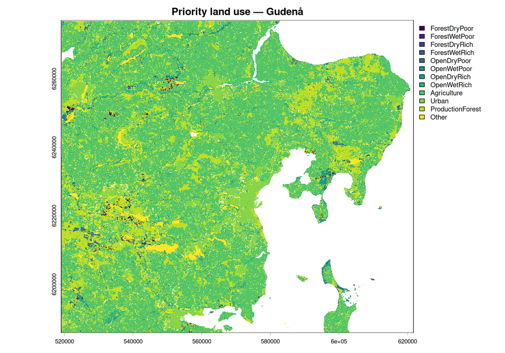

```r
plot(
  landuse_gudenaa,
  type = "classes",
  main = "Priority land use — Gudenå"
)
```

# 16 Interpretation

This output is a **current land-use predictor**, not a protection-status map. `Subclasses` contributes the distinction between forest nature and presumed managed forest, but Basemap supplies the forest footprint. Before modelling, inspect the audit and map, especially boundaries between `Forest*` and `ProductionForest`. If a separate authoritative unmanaged/natural-forest layer becomes available, merge it into `forest_nature_mask`; do not revert to using `Drevet Skov` alone for production forest. Checkpointing improves restartability, not the ecological certainty of this forest-management proxy.